# tidy-Copy1

- Introduction
- 1. Data Tidying
- 2. Data Visualisation
- 3. Modelling
  - 3.1 PCA
  - 3.2 K-Means
  - 3.3 DBSCAN
  - 3.4 Calculate Clustering Metrics
- 4. Visualise Clustering
- 5. Analysis
- 6. Conclusion

### Introduction

- The aim of this analysis is to cluster commercial electricity users based on consumption profiles using feature extraction (PCA) and machine learning clustering algorithms (K-Means and DBSCAN).
- The growth of intermittent electricity generation sources, such as wind, solar etc., on electricity grids has increased the challenge of balancing supply and demand. Instead of increasing supply to meet demand, shifting or curtailing demand using time-of-use tariffs and demand-side response has become increasingly important.
- In order to offer the appropriate time-of-use tariff and DSR products and incentives to users, it is useful for electricity suppliers and operators to have a clear understanding of user profiles. Fairly simple user categorisation based on industry or business type (e.g. office, grocer, school etc.) are insufficent as there can be significant variation in consumption profiles within these categories.
- The hypothesis of this study is that a machine learning clustering approach can provide more suitable and insightful user categorisation.
- This study uses anonymized 5-minute energy usage data for 100 commercial/ industrial sites for 2012 (Available at:https://open-enernoc-data.s3.amazonaws.com/anon/index.html). Commercial users in the dataset are currently categorised according to industry and sub-industry.

```python
import pandas as pd
import seaborn as sns
import matplotlib.pyplot as plt
import datetime
import numpy as np
```

### 1. Data Tidying

1. Rename columns, split date and time column, drop unnecessary columns.
2. Check and fill-in missing values

```python
commercial = df.copy()
#rename
commercial.rename(columns={'value':'kWh'},inplace=True)
#split date and time column
commercial[['date','time']] = commercial['dttm_utc'].str.split(' ',expand=True)
#drop unecessary columns
commercial = commercial.drop(['estimated','anomaly','timestamp'], axis=1)
```

There should be five-minute readings for each site for the entire year. In order to check for missing readings:

1. Create new df with 5 minute intervals for whole year for all sites
2. Merge left with the readings dataframe
3. Check for missing values

```python
# Define the start and end date
start_date = datetime.datetime(2012, 1, 1, 0, 5, 0)
end_date = datetime.datetime(2012, 12, 31, 23, 55, 0)
# Generate date range with 5-minute intervals
date_range = pd.date_range(start=start_date, end=end_date, freq='5T')
date_range = pd.DataFrame(date_range)
date_range.rename(columns={0:'dttm_utc'}, inplace=True)
#create list of unique SITE_IDs
sites = commercial['SITE_ID'].unique()
# Create a DataFrame with date_range for all sites
exp_date_range = pd.concat([date_range] * len(sites), ignore_index=True).astype(str)
# Create a DataFrame with list of SITE_IDs
repeat_site_ids = np.repeat(sites, len(date_range))
sites_ids = pd.DataFrame({'SITE_ID': repeat_site_ids})
#concatenate new dfs
date_time = pd.concat([exp_date_range, sites_ids], axis=1)
#left merge with industry
date_time = pd.merge(date_time, commercial, left_on=['dttm_utc','SITE_ID'], right_on=['dttm_utc','SITE_ID'],how='left')
```

Find sites with relatively high percentages of missing values

```python
#calculate nans per site
nan_count_per_site = date_time.groupby('SITE_ID')['kWh'].apply(lambda x: x.isna().sum()).reset_index()
#rename columns
nan_count_per_site.rename(columns={'kWh':'count'}, inplace=True)
#make percentage column
nan_count_per_site['percent_nan'] = nan_count_per_site['count'] / len(date_range) * 100
#sort by highest percentage
nan_count_per_site_sort = nan_count_per_site.sort_values(by='percent_nan', ascending=False)
nan_count_per_site_sort.head()
```

|  | SITE_ID | count | percent_nan |
| --- | --- | --- | --- |
| 93 | 767 | 3400 | 3.225592 |
| 8 | 22 | 3399 | 3.224644 |
| 35 | 137 | 839 | 0.795962 |
| 79 | 690 | 552 | 0.523684 |
| 17 | 44 | 552 | 0.523684 |

Sites 767 and 22 have > 3% of values missing, the remaining < 1%.  
Filter for sites 767 and 22 and evaluate which dates and times are affected

```python
#filter for sites 767 & 22
sites_767_22 = date_time[((date_time['SITE_ID'] == 767)|(date_time['SITE_ID'] == 22))].drop(['date','time'],axis=1).copy()
#create month,day columns to find common dates
sites_767_22[['date','time']] = sites_767_22['dttm_utc'].str.split(' ',expand=True).astype(str)
sites_767_22['month'] = sites_767_22['date'].str.split('-').str[1].astype('int64')
sites_767_22['day'] = sites_767_22['date'].str.split('-').str[2].astype('int64')
#filter for only NaNs
sites_767_22_nan_only = sites_767_22[sites_767_22['kWh'].isnull()]
#print unique entries in month and day columns
print("Month with NaNs:",sites_767_22_nan_only['month'].unique())
print("Days with NaNs:",sites_767_22_nan_only['day'].unique())
```

```
Month with NaNs: [1]
Days with NaNs: [ 1  2  3  4  5  6  7  8  9 10 11 12]
```

NaN readings at these sites mostly in the time period January 1st - 12th.  
There is not a particularly satisfactory method for filling in these readings, however it was decided to fill-in the missing values with data from the next matching time period at each site: next 12 days of data = Jan 13th-24th

```python
#filter for jan 13-24
nan_sites_jan_13_24 = sites_767_22[(sites_767_22['month'] == 1)&((sites_767_22['day'] > 12)&(sites_767_22['day'] < 25))].copy()
#replace days 13-23 with 1-12
nan_sites_jan_13_24['day'].replace(list(range(13,25)), list(range(1,13)), inplace=True)
#filter for jan 1-12
nan_sites_jan_1_12 = sites_767_22[(sites_767_22['month'] == 1)&((sites_767_22['day'] > 0)&(sites_767_22['day'] < 13))].copy()
#merge 13-24 to replace kwh in 1-12
merge = pd.merge(nan_sites_jan_1_12[['SITE_ID','dttm_utc','day','time']], nan_sites_jan_13_24[['SITE_ID','day','time','kWh']], on=(['SITE_ID','day','time']), how='left').drop(['day','time'], axis=1).rename(columns={'kWh_y':'kWh'}, inplace=False)
#merge with date_time
date_time_merge = pd.merge(date_time, merge, on=(['SITE_ID','dttm_utc']), how='left')
#replace kWh_x with kWh_y
date_time_merge['kWh_x'].fillna(value=date_time_merge['kWh_y'], inplace=True)
#drop kWh_y and remane kWh_x
date_time_merge = date_time_merge.drop('kWh_y', axis=1).rename(columns={'kWh_x':'kWh'}, inplace=False)
```

For missing readings at sites with less than 1% missing, back-fill the values from next time period (e.g. 00:10:00 = NaN, 00:15:00 = 6 => 00:10:00 = 6)

```python
#use bfill to fill nas
date_time_merge.fillna(method='bfill', inplace=True)
```

Finally, check for remaining missing values and ensure all sites have the same number of entries

```python
#check for remaining nas
nas = date_time_merge.isna().sum()
print("Number of NaNs:",nas)
#check each site still has same number of entries
siteid_count = date_time_merge['SITE_ID'].value_counts().reset_index()
siteid_count_unique = siteid_count['count'].unique()
print("All sites have :",siteid_count_unique,"entries")
```

```
Number of NaNs: dttm_utc        0
SITE_ID         0
kWh             0
INDUSTRY        0
SUB_INDUSTRY    0
SQ_FT           0
LAT             0
LNG             0
TIME_ZONE       0
TZ_OFFSET       0
date            0
time            0
dtype: int64
All sites have : [105407] entries
```

### 2. Data Visualisation

- There are 10 sub-industry categories for commercial users (see plot below). The most common commercial user categories are schools and grocers/markets (25).

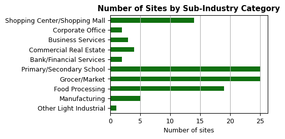

```python
#plot for number of sub-industry categories
plt.rcParams.update({'font.size': 9})
plt.figure(figsize=(4,2.5))
sns.countplot(data=info, y="SUB_INDUSTRY", width=0.5, linewidth=0.2, color='Green')
plt.xlabel("Number of sites")
plt.ylabel("")
plt.grid(axis='x')
plt.title("Number of Sites by Sub-Industry Category", fontweight='bold')
plt.show()
```

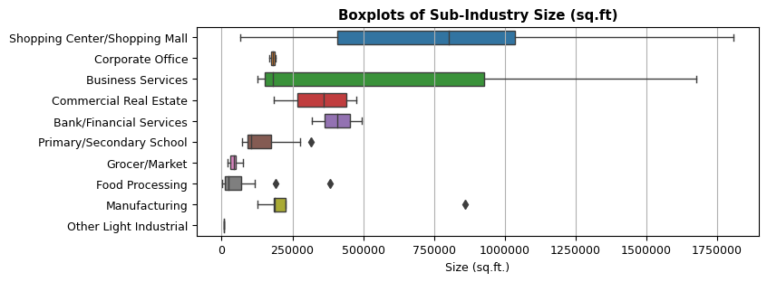

```python
#plot for boxplots of size of sub_industry categories
plt.rcParams.update({'font.size': 9})
plt.figure(figsize=(8,3))
sns.boxplot(data=info, x='SQ_FT', y="SUB_INDUSTRY", width=0.65, linewidth=1)
plt.xlabel("Size (sq.ft.)")
plt.ylabel("")
plt.ticklabel_format(style='plain', axis='x')
plt.grid(axis='x')
plt.title("Boxplots of Sub-Industry Size (sq.ft)", fontweight='bold')
plt.show()
```

Plot the annual electricity consumption profiles of each sub-industry category

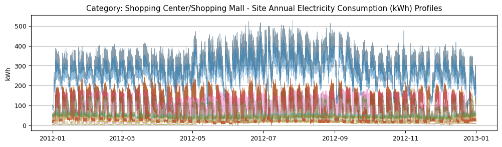

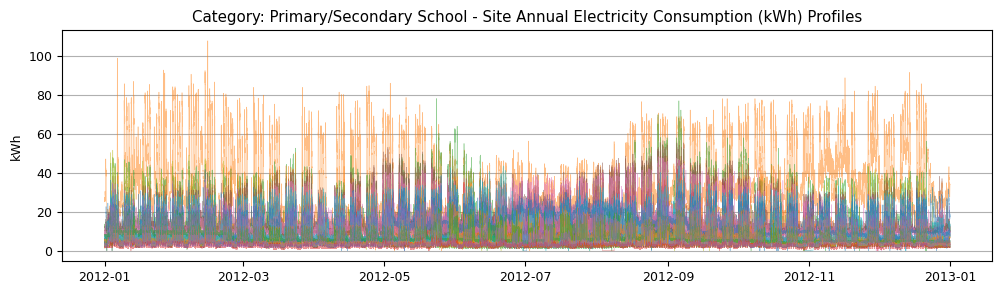

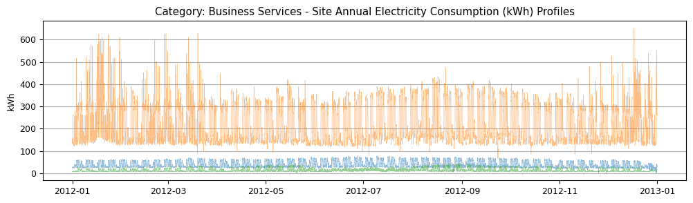

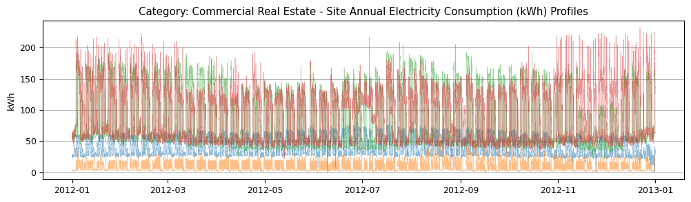

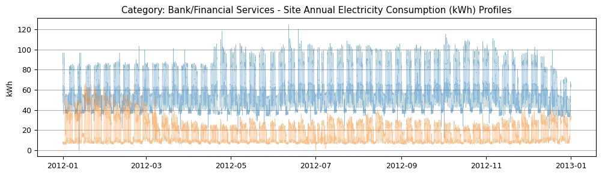

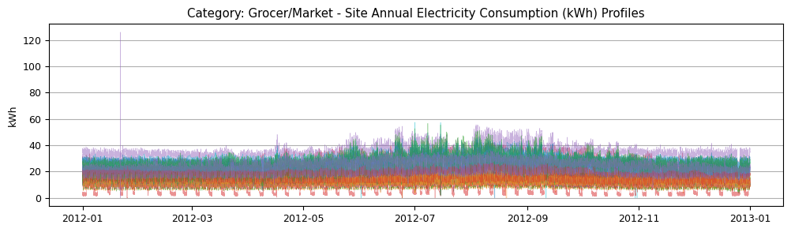

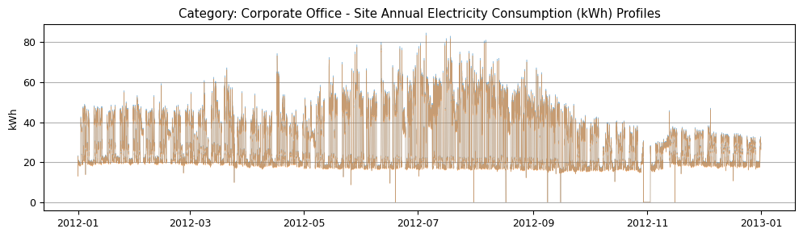

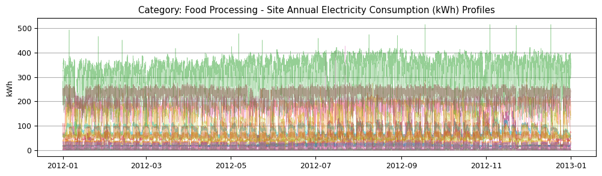

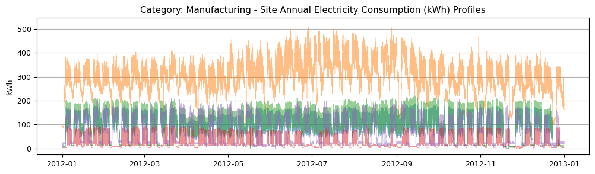

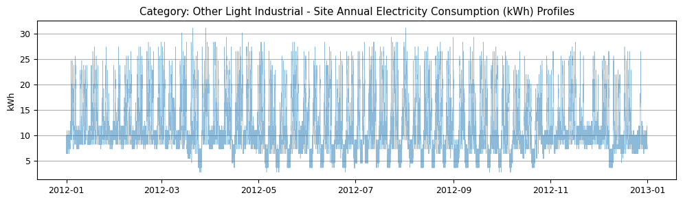

```python
#convert date/time column into datetime format
date_time_merge['dttm_utc'] = pd.to_datetime(date_time_merge['dttm_utc'])
#create sub_industry list
sub_industry_category = date_time_merge['SUB_INDUSTRY'].unique()
#plot each sub_industry
for i in sub_industry_category:
    cat_df = date_time_merge[date_time_merge['SUB_INDUSTRY'] == i]
    unique_sites = cat_df['SITE_ID'].unique()
    plt.figure(figsize=(12,3))
    plt.grid(axis='y')
    for site in unique_sites:
        subset = cat_df[cat_df['SITE_ID'] == site].copy()
        plt.plot(subset['dttm_utc'], subset['kWh'], linewidth=0.4, alpha=0.5)
        plt.ylabel("kWh")
        plt.title(f"Category: {i} - Site Annual Electricity Consumption (kWh) Profiles")
    plt.show()
```

A large outlier can be seen in the grocer/market plot. Remove this outlier from the dataset be replacing with next non-zero reading (zero may still be an erroneous reading) and replot

```
125.9456
19.782
Index([6752019], dtype='int64')
```

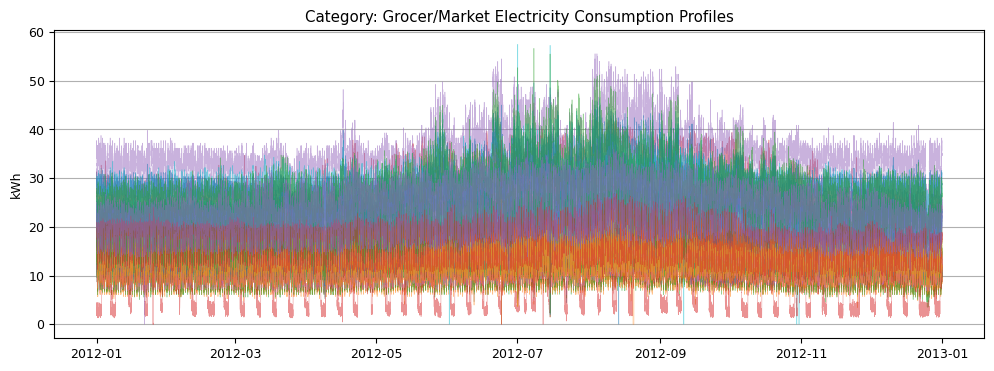

```python
#filter for grocer/market category
grocer = date_time_merge[date_time_merge['SUB_INDUSTRY'] == 'Grocer/Market']
#find max reading
outlier = max(grocer['kWh'])
print(outlier)
#this value matches the outlier. Check index and find next non-zero value
outlier_index = grocer[grocer['kWh'] == outlier].index
next_value = grocer.at[outlier_index[0]+2, 'kWh']
print(next_value)
#find index of outlier in date_time_merge df
original_outlier_index = date_time_merge[date_time_merge['kWh'] == outlier].index
print(original_outlier_index)
#replace original_outlier_index outlier with next_value
date_time_merge.at[original_outlier_index[0], 'kWh'] = next_value
#replot grocer/market plot to check outlier removed
cat_df = date_time_merge[date_time_merge['SUB_INDUSTRY'] == 'Grocer/Market']
unique_sites = cat_df['SITE_ID'].unique()
plt.figure(figsize=(12,4))
plt.grid(axis='y')
for site in unique_sites:
    subset = cat_df[cat_df['SITE_ID'] == site].copy()
    plt.plot(subset['dttm_utc'], subset['kWh'], linewidth=0.4, alpha=0.5)
    plt.ylabel("kWh")
    plt.title(f"Category: Grocer/Market Electricity Consumption Profiles")
plt.show()
```

The visualisation of consumption profiles shows the level of variance in each each sub-industry categorisation group. The results of the clustering below will be compared against these original categories.

### 3. Modelling

This section will follow these steps:

1. Conduct PCA on 5-minute yearly readings
   - The dataset has high-dimensionality (100 x 105407). K-Means uses the distance between points to create clusters. The high-dimesionality can cause issues such as the 'curse of dimensionality', whereby the sparsity of data points reduces the ability of the algorithm to identify meaningful clusters, and increased computational requirements.
   - Therefore, a principal component analysis (PCA) was conducted to reduce the dimensionality of the dataset before clustering.
2. K-Means
   - Perform K-Means clustering.
3. DBSCAN
   - Perform DBSCAN clustering.

#### 3.1 PCA

Create a wide dataset of only kWh values suitable for next steps

```python
#create clustering df
cluster_df = date_time_merge.pivot(index='SITE_ID',columns='dttm_utc',values='kWh')
cluster_np = cluster_df.to_numpy()
```

Import required clustering modules

```python
import sklearn as sk
from sklearn.preprocessing import StandardScaler
from sklearn.decomposition import PCA
from sklearn import metrics
from sklearn.metrics import silhouette_score
from sklearn.cluster import KMeans
from sklearn.cluster import DBSCAN
```

The data is standardised before conducting PCA. Standardisation (z-score) ensures that samples with higher readings do not exert an undue influence on variance allowing the PCA to better capture the underlying structure of the data.

```python
#standardise data
scalar = StandardScaler()
cluster_np_scaled = scalar.fit_transform(cluster_np)
#conduct PCA
pca = PCA(svd_solver='randomized')
pca_results = pca.fit_transform(cluster_np_scaled)
```

#### 3.2 K-Means

- For K-Means the number of clusters must be specified as a parameter. An elbow plot is often used to find the optimum number of clusters. The elbow plot is designed to show the point at which increasing the number of clusters does not result in increasing inertia (Inertia = within-cluster sum-of-squares. A low value is better because it indicates more compact clustering).
- Increased numbers of clusters is often assiciated with a decrease in interpretability.
- The silhoutte score can also be used as a clustering metric (silhouette score = a measurement of average distances between within- and outside- cluster points with values between 1 and -1. A high value is an indicator of well separated clusters.)
- This analysis will use inertia and silhouette plots to evaluate the optimum number of clusters.

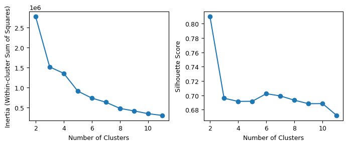

```python
import warnings
warnings.filterwarnings("ignore")

#Run kmeans algortihm over 2-10 clusters and store results
inertia = []
silhouette_scores = []
labels_dict = []
for k in range(2, 12):
    kmeans = KMeans(n_clusters=k, init='k-means++', n_init='auto', random_state=42).fit(pca_results)
    inertia.append(kmeans.inertia_)
    labels = kmeans.fit_predict(pca_results)
    labels_dict.append(labels)
    silhouette_avg = silhouette_score(pca_results, labels)
    silhouette_scores.append(silhouette_avg)

#Plot results
metrics = [inertia, silhouette_scores]
y_labels = ['Inertia (Within-cluster Sum of Squares)', 'Silhouette Score']
plot_nums = [1,2]
plt.figure(figsize=(7, 3))
for m, label, n in zip(metrics, y_labels, plot_nums):
    plt.subplot(1, 2, n)
    plt.plot(range(2, 12), m, marker='o')
    plt.xlabel('Number of Clusters')
    plt.ylabel(f'{label}')
    plt.title('')

plt.tight_layout()
plt.show()


warnings.resetwarnings()
```

- The elbow method for inertia shows a clear turn at 3 clusters. However, the silhouette score is highest (after 2) at 6 clusters and the inertia decreases significantly with 6 clusters.
- Returning to the original aim of the analysis, given that there were 10 original sub-industries, it is reasonable for interpretability for there to be 6 new clusters - where there is low inertia and the highest silhouette score.

#### 3.3 DBSCAN

- Density-Based Spatial Clustering of Applications with Noise (DBSCAN) finds dense clusters, but also allows outliers to remain as noise and unclustered. This can lead to more distinct and compact clusters than other methods, e.g. k-means.
- DBSCAN requires two parameters to be set: eps and min_samples
  - eps = the max distance between two points to be considered as part of the same cluster
  - min_sample = the minimum number or points required to form a cluster
- In order to find the optimum parameters for DBSCAN, a range of eps and min_sample parameters are evaluated according to silhouette score. The parameters which result in the best silhouette score are considered optimal.

```python
eps_range = np.linspace(10, 800, 80)
min_samples_range = range(2, 5)

best_eps = None
best_min_samples = None
best_score = -1

for eps in eps_range:
    for min_samples in min_samples_range:
        dbscan = DBSCAN(eps=eps, min_samples=min_samples)
        labels = dbscan.fit_predict(pca_results)
        if sum(np.unique(labels)) > 2:
            silhouette_avg = silhouette_score(pca_results, labels)
            if silhouette_avg > best_score:
                best_score = silhouette_avg
                best_eps = eps
                best_min_samples = min_samples
                best_clusters = len(set(labels)) - (1 if -1 in labels else 0)
                best_noise = list(labels).count(-1)
                best_labels = labels

#print results
print(f"Optimum eps: {best_eps}")
print(f"Optimum min_samples: {best_min_samples}")
print(f"Optimum silhouette score: {best_score}")
print(f"(Result) Number of clusters: {best_clusters}")
print(f"(Result) Number of samples in noise: {best_noise}")

#run algorithm with optimum parameters
db = DBSCAN(eps=best_eps, min_samples=best_min_samples).fit(pca_results)
labels_dbscan = db.labels_
sc = db.fit_predict(pca_results)

#run checks to compare with optimum results
# n_clusters_ = len(set(labels_dbscan)) - (1 if -1 in labels_dbscan else 0)
# n_noise_ = list(labels_dbscan).count(-1)
# print(n_clusters_)
# print(n_noise_)
# print(silhouette_score(pca_results, sc))
# print(np.unique(labels_dbscan, return_counts=True))
```

```
Optimum eps: 120.0
Optimum min_samples: 3
Optimum silhouette score: 0.6357663464033348
(Result) Number of clusters: 5
(Result) Number of samples in noise: 9
```

#### 3.4 Calculate Clustering Metrics

Calculate clustering metrics (inertia and silhouette score) for original clustering based on sub-industry category.

```python
#create a numpy array of original classifications
#get site ids in order from clustering df
original_clusters = pd.DataFrame(cluster_df.index)
#merge with info to get sub_industry and drop sites_ids
original_clusters = pd.merge(original_clusters, info[['SITE_ID','SUB_INDUSTRY']], how='left').drop('SITE_ID', axis=1)
#factorize to convert industries to numbers (required for 'c' parameter)
original_clusters['SUB_INDUSTRY'] = pd.factorize(original_clusters['SUB_INDUSTRY'])[0] + 1
#convert to mumpy array
original_clusters = original_clusters.to_numpy().ravel()
```

Define function for calculating inertia

```python
def calculate_inertia(data, cluster_labels):
    num_clusters = np.max(cluster_labels) + 1
    centroids = np.zeros((num_clusters, data.shape[1]))
    inertia = 0

    for cluster_idx in range(num_clusters):
        cluster_points = data[cluster_labels == cluster_idx]
        if len(cluster_points) > 0:
            centroids[cluster_idx] = np.mean(cluster_points, axis=0)

    for i in range(len(data)):
        cluster_idx = cluster_labels[i]
        centroid = centroids[cluster_idx]
        distance = np.sum((data[i] - centroid) ** 2)
        inertia += distance

    return inertia
```

- Calculate the inertia and silhouette scores of original sub-industry categories.
- Calculate inertia and silhouette scores of DBSCAN *excluding* 'noise' points. Excluding the noise points allows comparison of the silhouette score of clustered points, and can represent a better metric to compare to other clustering methods, whilst also acknoledging in the analysis that some points remain unassigned.
- Display results in table.

```python
#calculate original inertia score
original_inertia = calculate_inertia(pca_results, original_clusters)
#calculate original silhouette score
original_silscore = silhouette_score(pca_results, original_clusters)
#calculate DBSCAN clustering inertia and including noise
dbscan_inertia = calculate_inertia(pca_results, best_labels)
#calculate DBSCAN clustering inertia and silhouette score excluding noise
#create boolean mask
noise = np.isin(best_labels, -1)
#filter array and labels
pca_excl_noise = pca_results[~noise]
excl_noise_labels = best_labels[~noise]
#inertia excl. noise
excl_noise_inertia = calculate_inertia(pca_excl_noise, excl_noise_labels)
#silhouette score excl. noise
excl_noise_silscore = silhouette_score(pca_excl_noise, excl_noise_labels)
#plot table
print(48*"_")
print("cluster method\t\t inertia\tsilscore")
print("original sub-industry\t {:,.0f}\t {:.2f}".format(original_inertia, original_silscore))
print("kmeans\t\t\t {:,.0f}\t {:.2f}".format(inertia[4], silhouette_scores[4]))
print("DBSCAN (incl. noise)\t {:,.0f}\t {:.2f}".format(dbscan_inertia, best_score))
print("DBSCAN (excl. noise)\t {:,.0f}\t {:.2f}".format(excl_noise_inertia, excl_noise_silscore))
print(48*"_")
```

```
________________________________________________
cluster method		 inertia	silscore
original sub-industry	 7,436,491	 -0.27
kmeans			 731,280	 0.70
DBSCAN (incl. noise)	 3,457,252	 0.64
DBSCAN (excl. noise)	 364,592	 0.74
________________________________________________
```

- The original sub-industry classification has the worst inertia and silhouette scores.
- K-Means has better metrics than the DBSCAN incl. noise.
- However, the DBSCAN clustering without noise has better inertia and silhouette scores than the k-means. This can be visualised in the plots below.

### 4. Visualise Clustering

- As it is not possible to visualise the clusterings for dimensions 100x100, the plots below use the first two principal components of the PCA results as the x and y axes.
- This allows a visual representation of the clustering where each point represents a commercial user and the colour represents the cluster membership.
- It's important to note that colours cannot be compared across graphs e.g. yellow dots on one plot have no relation to yellow dots on another. Rather the key insight is that dots of the same colour on a graph are in the same cluster.

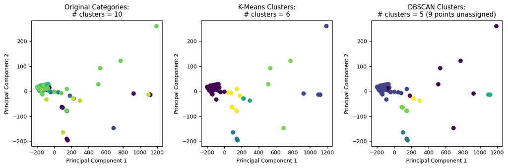

```python
#take first two principal components of PCA df
two_pp = pca_results[:, :2]
#plot results
cluster_plot_data = [original_clusters, labels_dict[4], best_labels]
sil_scores = [original_silscore, silhouette_scores[4], best_score]
titles = ['Original Categories', 'K-Means Clusters', 'DBSCAN Clusters']
plot_numbers = [1,2,3]
cluster_numbers = ['10', '6', '5 (9 points unassigned)']
plt.figure(figsize=(12, 4))
dot_size = 40
for data, score, name, number, cnumber in zip(cluster_plot_data, sil_scores, titles, plot_numbers, cluster_numbers):
    plt.subplot(1, 3, number)
    plt.scatter(two_pp[:, 0], two_pp[:, 1], c=data, cmap='viridis', s=dot_size)
    plt.title(f"{name}:\n# clusters = {cnumber}")
    plt.xlabel('Principal Component 1')
    plt.ylabel('Principal Component 2')
plt.tight_layout()
plt.show()
```

Plot the DBSCAN clustering results by original sub-industry category

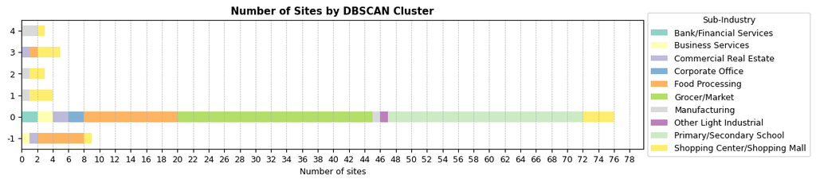

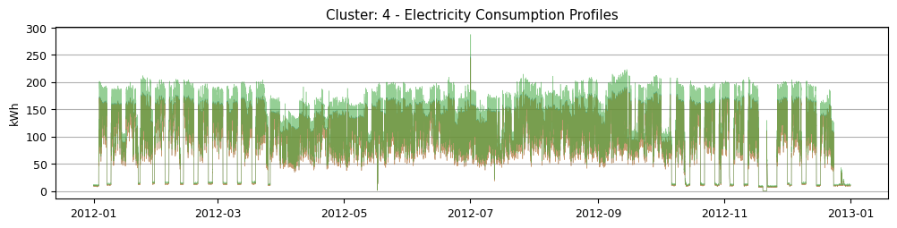

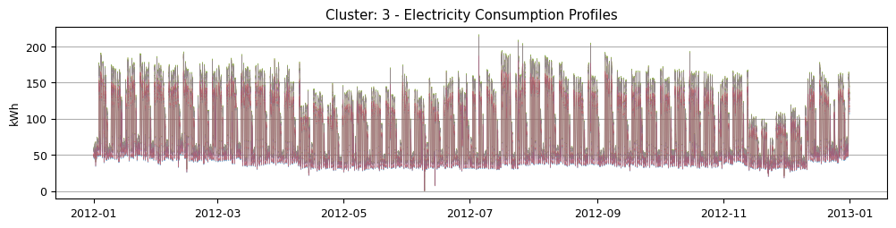

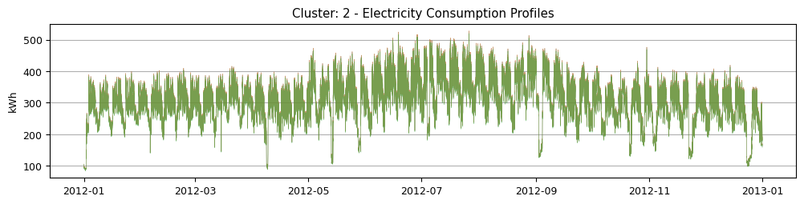

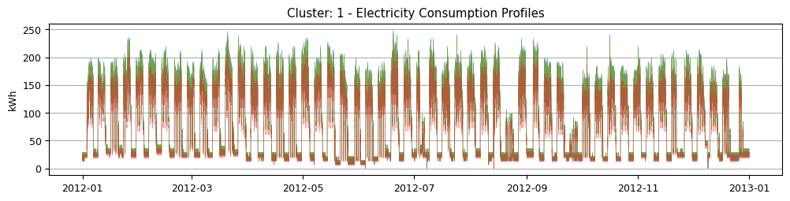

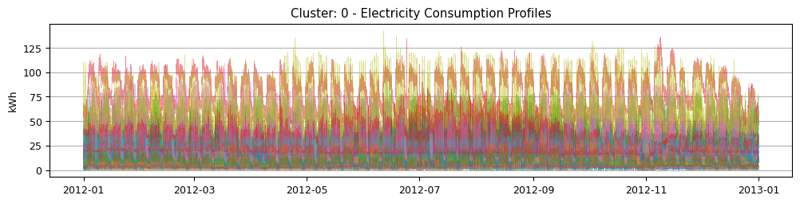

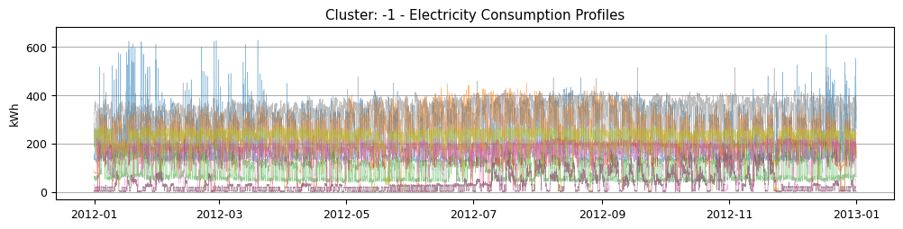

```python
#add dbscan cluster membership to info
#convert dbscan labels to df
best_labels_df = pd.DataFrame(best_labels).rename(columns={0:"dbscan_cluster"})
#assign dbscan clusters to SITE_IDs
index = cluster_df.reset_index()
dbscan_site_clusters = pd.concat([index['SITE_ID'], best_labels_df], axis=1)
#merge with info for plotting
info_dbscan = pd.merge(info, dbscan_site_clusters, on='SITE_ID', how='left')
info_dbscan_grouped = info_dbscan.groupby(['dbscan_cluster', 'SUB_INDUSTRY']).size().unstack(fill_value=0)
#plot for number of sub-industry categories
plt.rcParams.update({'font.size': 9})
ax = info_dbscan_grouped.plot(kind='barh', stacked=True, colormap='Set3', figsize=(12,2.5))
ax.set_xticks(np.arange(0, 80, 2))
ax.set_xlabel("Number of sites")
ax.set_ylabel("")
ax.xaxis.grid(True, linestyle='--', linewidth=0.5)
ax.set_title("Number of Sites by DBSCAN Cluster", fontweight='bold')
legend = ax.legend(loc='center left', bbox_to_anchor=(1, 0.5))
legend.set_title('Sub-Industry')
plt.show()
#merge with date_time_merge for plotting
dbscan_cluster_plots = pd.merge(date_time_merge, dbscan_site_clusters, on='SITE_ID', how='left')
#create cluster list
dbscan_clusters = dbscan_cluster_plots['dbscan_cluster'].unique()
dbscan_clusters = np.sort(dbscan_clusters)[::-1]
#plot each cluster
for i in dbscan_clusters:
    cluster_members = dbscan_cluster_plots[dbscan_cluster_plots['dbscan_cluster'] == i]
    unique_sites = cluster_members['SITE_ID'].unique()
    plt.figure(figsize=(12,2.5))
    plt.grid(axis='y')
    for site in unique_sites:
        subset = cluster_members[cluster_members['SITE_ID'] == site].copy()
        plt.plot(subset['dttm_utc'], subset['kWh'], linewidth=0.4, alpha=0.5)
        plt.ylabel("kWh")
        plt.title(f"Cluster: {i} - Electricity Consumption Profiles")
    plt.show()
```

### 5. Analysis

1. Both K-Means and DBSCAN have formed more appropriate clusterings than the original categories; the inertia and silhouette scores are improved, meaning the clusters are more distinct and better defined in DBSCAN and K-Means. This can be observed from plots above.
2. The plots highlight the key difference between K-Means and DBSCAN. The DBSCAN is able to exclude 'noisy' points from clusters. As a result the DBSCAN clusters, excluding the noise, are more defined and compact. By contrast, the K-Means algorithm is forced to include all points and therefore the clusters can be less compact, resulting in higher inertia and lower silhouette scores.
3. The DBSCAN has clustered 76 sites into one group; '0'. Further analysis is required to show the similarity between these sites.
4. The DBSCAN clustering has shown how sites with different sub-industries have similar profiles e.g. cluster '3' has 1 commerical real estate site, 1 food processing site and 3 shopping centre/mall sites.
5. There are 9 sites in the 'noise' (-1 above) of the DBSCAN.

### 6. Conclusion

- Returning to the aim of the study, the DBSCAN results are likely more useful than the K-Means results. As an electricity supplier or operator looking to offer time-of-use tariffs or to introduce DSR to users, the clusters need to prioritise compactness and internal consistency to ensure that product offerings are suitable for that customer segment. Clusters of disimilar customers will be less useful, although the level of disimilarity acceptable would need to be assessed.
- The DBSCAN results can therefore offer more opportunity because of the compactness of the clusters. The noise points could be treated individually by the electricity provider.